# Multiple Linear Regression Problem Set

[figure not shown]

```r
# This appears to be a reasonable model by all the summary statistics

# check assumptions
par(mfrow = c(2,2))
```

[figure not shown]

```r
plot(myModel2)
```

```r
# This appears to be much better
shapiro.test(myModel2$residuals) # we definitively pass normality
```

```
##
##  Shapiro-Wilk normality test
##
## data:  myModel2$residuals
## W = 0.98926, p-value = 0.6765
```

```r
car::ncvTest(myModel2) # we are close on homoscedasticity but pass at alpha > .05
```

```
## Non-constant Variance Score Test
## Variance formula: ~ fitted.values
## Chisquare = 3.082996, Df = 1, p = 0.079115
```

```r
# check for outliers
myModel2$residuals[abs(myModel2$residuals) > 2*sd(myModel2$residuals)]
```

```
##         8        28        39        67        68        73        75
## -68362.43 -58614.85 -64882.13  54457.38  54735.45 -62145.13  65268.19
```

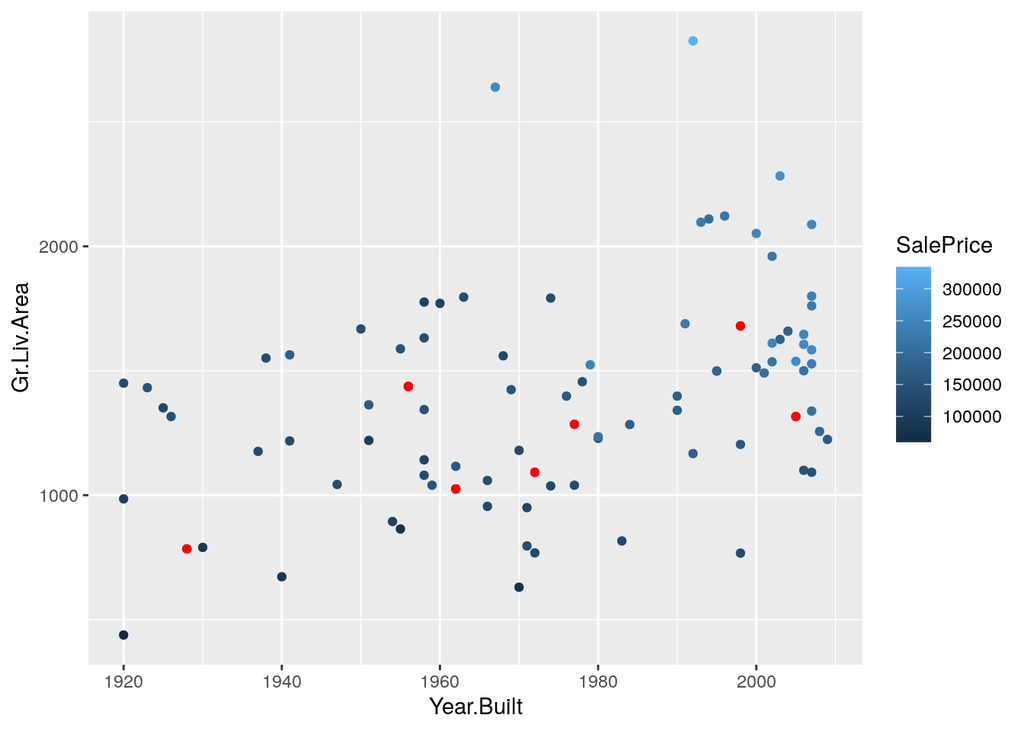

```r
# we have 7 possible outliers

# check for leverage
plot(myModel2, which = 4)
# we have a few points of high leverage, let's look at our model

ggplot() +
  geom_point(data = ames2, aes(x = Year.Built, y = Gr.Liv.Area, color = SalePrice)) +
  geom_point(data = ames2[c(8, 28, 39, 67, 68, 73, 75, 8, 39, 95),], aes(x = Year.Built, y = Gr.Liv.Area), color = 'red')
# We see these points are squarely in our data, they may skew our results somewhat, but it would be
# too aggressive to cut these points.  let's procede with myModel2

# Finally, in our analysis - we should not that we had to remove a subset of points that were exceptionally
# expensive and/or exceptionally old.  We can hypothesize that there is another factor that
# contributes to exceptionally expensive house (e.g., neighborhood) and exceptionally older houses
# may warrant higher prices based on an "antique effect".  Further analysis is warranted for a more refined model.
```

[output not shown]

## 1.5 Prediction

Predict the cost of a house built in 1984 that is 2002 square feet with 90% confidence on the mean cost.

```r
predict(myModel2, list(Year.Built = 1984, Gr.Liv.Area = 2002), interval = 'confidence', level = .9)
```

```
##        fit      lwr      upr
## 1 219396.7 210815.3 227978.2
```

```r
# ~$219K +/- $8K
```

If someone asked you to predict the cost of a house built in in Ames based on this model and this data for a house built in 1900, would this make good sense?

```
This likely would not make a lot of sense.  First, we would be extrapolating beyond the majority of the data which is bad practice.
Second, it may be the case that older houses are generally less valuable to a point as they are
generally more worn.  However, exceptionally old houses may increase in value for a variety of reasons
including historic value, location (often older houses are in older areas), and the fact that
they are still extant means they were valued and well maintained.
```

## 1.6 Visualize the Data

Create a contour plot that shows the contours for predicted sale price with the year built on the x axis and the gross living area on the y axis. Overlay your observations on the graph.

```r
# We can build a surface of every two years and every 50 square feet (this is overkill, but why not)
mySurface <- expand_grid(Year.Built = seq(min(ames2$Year.Built), max(ames2$Year.Built), by = 2),
                         Gr.Liv.Area = seq(min(ames2$Gr.Liv.Area), max(ames2$Gr.Liv.Area), by = 50))
# We predict the response for each combination
mySurface$SalePrice <- predict(myModel2, mySurface)

# View our data to make sure it is structured as we need it
head(mySurface)
```

```
## # A tibble: 6 x 3
##   Year.Built Gr.Liv.Area SalePrice
##        <dbl>       <dbl>     <dbl>
## 1       1920         438    44706.
## 2       1920         488    48362.
## 3       1920         538    52018.
## 4       1920         588    55674.
## 5       1920         638    59330.
## 6       1920         688    62986.
```

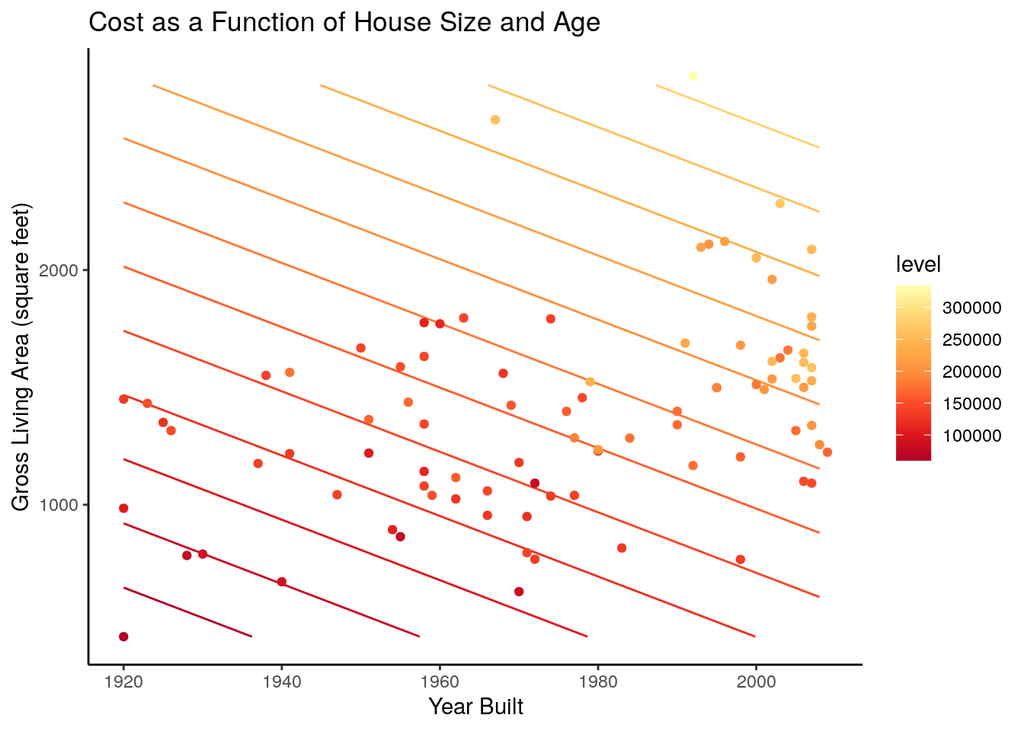

```r
# plot the contours and observations
ggplot() +
  # geom_contour gives us a contour plot
  geom_contour(data = mySurface, aes(x = Year.Built, y = Gr.Liv.Area, z = SalePrice, color = after_stat(level))) +
  # geom_point gives us our data points
  geom_point(data = ames2, aes(x = Year.Built, y = Gr.Liv.Area, color = SalePrice)) +
  # We can choose colors we like
  scale_color_distiller(palette = 'YlOrRd', direction = -1)  + # change the color from indecipherable blue
  # Clean up the graph
  xlab('Year Built') +
  ylab('Gross Living Area (square feet)') +
  ggtitle('Cost as a Function of House Size and Age') +
  theme_classic()
```

Interpret the graph.

```
We can visually see what we saw matehmatically, houses generally get more expensive as they get larger and newer.
We can see some distinctions.  For example, you can see some more expensive houses (observed) that are new
and about 2500 square feet that are yellow orange (i.e., more expensive), but would be predicted to cost less.
This makes sense as there are certainly other factors that affect house price (e.g., location)
```

Would it make sense to use your model to predict the price of houses that are in the region bounded by $Square Feet > 2000$ and $Age < 1960$? Why or why not?

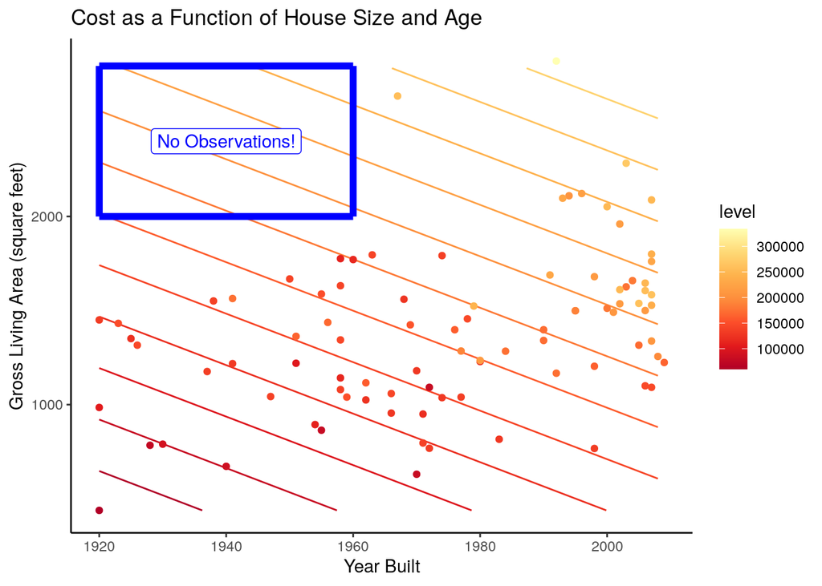

```r
# It would be a bad choice.  We have no observations in this region of the design space
# We do have points that are in one or the other of those two bounds.
# We cannot trust that region, however, because it is uninformed by any observations
# We can see this visually

# Produce our initial graph
ggplot() +
  geom_contour(data = mySurface, aes(x = Year.Built, y = Gr.Liv.Area, z = SalePrice, color = after_stat(level))) +
  geom_point(data = ames2, aes(x = Year.Built, y = Gr.Liv.Area, color = SalePrice)) +
  scale_color_distiller(palette = 'YlOrRd', direction = -1)  + # change the color from indecipherable blue
  xlab('Year Built') +
  ylab('Gross Living Area (square feet)') +
  ggtitle('Cost as a Function of House Size and Age') +
  theme_classic() +
  # Add a box to outline the prediction area in question
  geom_segment(aes(x = 1920, xend = 1920, y = 2000, yend = 2800), color = 'blue', size = 2) +
  geom_segment(aes(x = 1960, xend = 1960, y = 2000, yend = 2800), color = 'blue', size = 2) +
  geom_segment(aes(x = 1920, xend = 1960, y = 2000, yend = 2000), color = 'blue', size = 2) +
  geom_segment(aes(x = 1920, xend = 1960, y = 2800, yend = 2800), color = 'blue', size = 2) +
  geom_label(aes(x = 1940, y = 2400, label = 'No Observations!'), color = 'blue')
```

```r
# We can actually expand this region of space that is unfilled or poorly filled by observations, but
# that is a bit harder to graph, though easy to imagine
# As we move into latin hypercubes, we'll talk about the concept of 'space filling designs'
# We haven't gotten there yet, but you can conceptualize the concept very well.
```

# 2 Commo Conceptual

In a problem set on ANOVA, we had data bout the relationship between one of five commo sets, that were each defined as having some weight, range, bandwidth, error rate, and time value, and the number of kills achieved and losses received in a simulation. That data set is available here .

Consider a situation where you did not have information about the what the system numbers were (i.e., you drop the `system` column from your data set). Look at the pairs plots for the variables. Would it make sense to try to do a multiple linear regression with this data? Why or why not?

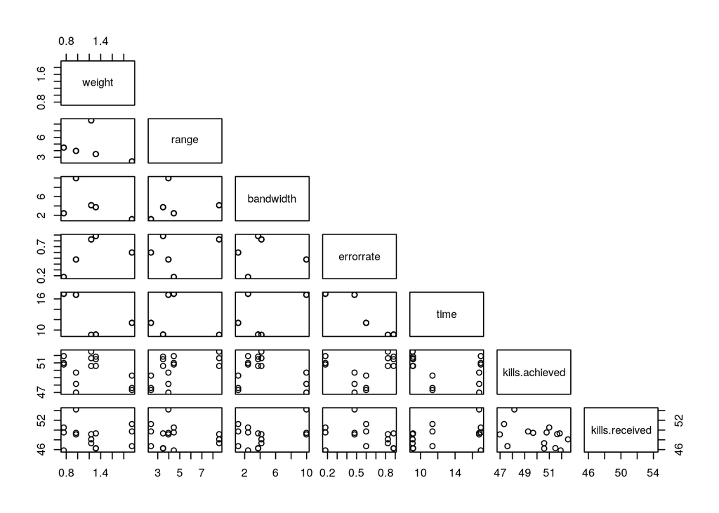

```r
commo <- read.csv('../_Chapter3_1_ProblemSets/commo.csv')
commo <- commo %>% select(-system)
pairs(commo, upper.panel = NULL)
```

```r
# We see clear evidence of patterns associated among our potential predictor variables
# This makes sense as we know that this data was grouped by system numbers so there
# is a relationship among the independent variables (i.e. system type).
# We also are having a hard time distinguishing a clear linear relationship among the kills
# and any given potential predictor.
# I would not use this data as is to model the results in a linear regression
```